# Final Project

Kiranmayee Nimashakavi,…

# 1 Introduction

### 1.0.1 Title of Project

The title of our project is “House Price Prediction” based on King County dataset.

### 1.0.4 Description of the dataset

- id - Unique ID for each home sold
- date - Date of the home sale
- price - Price of each home sold
- bedrooms - Number of bedrooms
- bathrooms - Number of bathrooms, where .5 accounts for a room with a toilet but no shower
- sqft_living - Square footage of the apartments interior living space
- sqft_lot - Square footage of the land space
- floors - Number of floors
- waterfront - A dummy variable for whether the apartment was overlooking the waterfront or not
- view - An index from 0 to 4 of how good the view of the property was
- condition - An index from 1 to 5 on the condition of the apartment,
- grade - An index from 1 to 13, where 1-3 falls short of building construction and design, 7 has an average level of construction and design, and 11-13 have a high quality level of construction and design.
- sqft_above - The square footage of the interior housing space that is above ground level
- sqft_basement - The square footage of the interior housing space that is below ground level
- yr_built - The year the house was initially built
- yr_renovated - The year of the house’s last renovation
- zipcode - What zipcode area the house is in
- lat - Lattitude
- long - Longitude
- sqft_living15 - The square footage of interior housing living space for the nearest 15 neighbors
- sqft_lot15 - The square footage of the land lots of the nearest 15 neighbors

### 1.0.5 What are the variables?

### 1.0.6 Goal of this model

The goal of the model we are creating is to accurately predict the price of the houses.

### 1.0.7 Dataset structure

We can see the structure of the dataset below

```r
housing_data <-read.csv("kc_house_data.csv",as.is = FALSE )



str(housing_data)
```

```
## 'data.frame':    21613 obs. of  21 variables:
##  $ id           : num  7.13e+09 6.41e+09 5.63e+09 2.49e+09 1.95e+09 ...
##  $ date         : Factor w/ 372 levels "20140502T000000",..: 165 221 291 221 284 11 57 252 340 306 ...
##  $ price        : num  221900 538000 180000 604000 510000 ...
##  $ bedrooms     : int  3 3 2 4 3 4 3 3 3 3 ...
##  $ bathrooms    : num  1 2.25 1 3 2 4.5 2.25 1.5 1 2.5 ...
##  $ sqft_living  : int  1180 2570 770 1960 1680 5420 1715 1060 1780 1890 ...
##  $ sqft_lot     : int  5650 7242 10000 5000 8080 101930 6819 9711 7470 6560 ...
##  $ floors       : num  1 2 1 1 1 1 2 1 1 2 ...
##  $ waterfront   : int  0 0 0 0 0 0 0 0 0 0 ...
##  $ view         : int  0 0 0 0 0 0 0 0 0 0 ...
##  $ condition    : int  3 3 3 5 3 3 3 3 3 3 ...
##  $ grade        : int  7 7 6 7 8 11 7 7 7 7 ...
##  $ sqft_above   : int  1180 2170 770 1050 1680 3890 1715 1060 1050 1890 ...
##  $ sqft_basement: int  0 400 0 910 0 1530 0 0 730 0 ...
##  $ yr_built     : int  1955 1951 1933 1965 1987 2001 1995 1963 1960 2003 ...
##  $ yr_renovated : int  0 1991 0 0 0 0 0 0 0 0 ...
##  $ zipcode      : int  98178 98125 98028 98136 98074 98053 98003 98198 98146 98038 ...
##  $ lat          : num  47.5 47.7 47.7 47.5 47.6 ...
##  $ long         : num  -122 -122 -122 -122 -122 ...
##  $ sqft_living15: int  1340 1690 2720 1360 1800 4760 2238 1650 1780 2390 ...
##  $ sqft_lot15   : int  5650 7639 8062 5000 7503 101930 6819 9711 8113 7570 ...
```

# 2 Method

## 2.1 Data Cleaning

### 2.1.1 Investigations - Visually looking at data statistics

Now we investigate the dataset to see what actions we need to take with the dataset before creating a model

```r
Hmisc::html(Hmisc::describe(housing_data[,1:21]), where=c('cwd', 'tmp'))
```

housing_data[, 1:21]  
21 Variables 21613 Observations

id

```
         n   missing  distinct      Info      Mean       Gmd       .05       .10
     21613         0     21436         1  4.58e+09 3.296e+09 5.125e+08 1.036e+09
       .25       .50       .75       .90       .95
 2.123e+09 3.905e+09 7.309e+09 8.732e+09 9.297e+09
```

| lowest : | 1000102 | 1200019 | 1200021 | 2800031 | 3600057 |
| --- | --- | --- | --- | --- | --- |
| highest: | 9842300095 | 9842300485 | 9842300540 | 9895000040 | 9900000190 |

date

| n | missing | distinct |
| --- | --- | --- |
| 21613 | 0 | 372 |

| lowest : | 20140502T000000 | 20140503T000000 | 20140504T000000 | 20140505T000000 | 20140506T000000 |
| --- | --- | --- | --- | --- | --- |
| highest: | 20150513T000000 | 20150514T000000 | 20150515T000000 | 20150524T000000 | 20150527T000000 |

price

```
        n  missing distinct     Info     Mean      Gmd      .05      .10      .25
    21613        0     4028        1   540088   329387   210000   245000   321950
      .50      .75      .90      .95
   450000   645000   887000  1156480
```

lowest : 75000 78000 80000 81000 82000 , highest: 5350000 5570000 6885000 7062500 7700000

bedrooms

| n | missing | distinct | Info | Mean | Gmd | .05 | .10 | .25 | .50 | .75 | .90 | .95 |
| --- | --- | --- | --- | --- | --- | --- | --- | --- | --- | --- | --- | --- |
| 21613 | 0 | 13 | 0.871 | 3.371 | 0.946 | 2 | 2 | 3 | 3 | 4 | 4 | 5 |

lowest : 0 1 2 3 4 , highest: 8 9 10 11 33

```
 Value          0     1     2     3     4     5     6     7     8     9    10    11
 Frequency     13   199  2760  9824  6882  1601   272    38    13     6     3     1
 Proportion 0.001 0.009 0.128 0.455 0.318 0.074 0.013 0.002 0.001 0.000 0.000 0.000

 Value         33
 Frequency      1
 Proportion 0.000
```

bathrooms

| n | missing | distinct | Info | Mean | Gmd | .05 | .10 | .25 | .50 | .75 | .90 | .95 |
| --- | --- | --- | --- | --- | --- | --- | --- | --- | --- | --- | --- | --- |
| 21613 | 0 | 30 | 0.974 | 2.115 | 0.8444 | 1.00 | 1.00 | 1.75 | 2.25 | 2.50 | 3.00 | 3.50 |

lowest : 0.00 0.50 0.75 1.00 1.25 , highest: 6.50 6.75 7.50 7.75 8.00

sqft_living

| n | missing | distinct | Info | Mean | Gmd | .05 | .10 | .25 | .50 | .75 | .90 | .95 |
| --- | --- | --- | --- | --- | --- | --- | --- | --- | --- | --- | --- | --- |
| 21613 | 0 | 1038 | 1 | 2080 | 978.4 | 940 | 1090 | 1427 | 1910 | 2550 | 3250 | 3760 |

lowest : 290 370 380 384 390 , highest: 9640 9890 10040 12050 13540

sqft_lot

| n | missing | distinct | Info | Mean | Gmd | .05 | .10 | .25 | .50 | .75 | .90 | .95 |
| --- | --- | --- | --- | --- | --- | --- | --- | --- | --- | --- | --- | --- |
| 21613 | 0 | 9782 | 1 | 15107 | 17855 | 1800 | 3322 | 5040 | 7618 | 10688 | 21398 | 43339 |

lowest : 520 572 600 609 635 , highest: 982998 1024068 1074218 1164794 1651359

floors

| n | missing | distinct | Info | Mean | Gmd |
| --- | --- | --- | --- | --- | --- |
| 21613 | 0 | 6 | 0.823 | 1.494 | 0.5563 |

lowest : 1.0 1.5 2.0 2.5 3.0 , highest: 1.5 2.0 2.5 3.0 3.5

```
 Value        1.0   1.5   2.0   2.5   3.0   3.5
 Frequency  10680  1910  8241   161   613     8
 Proportion 0.494 0.088 0.381 0.007 0.028 0.000
```

waterfront

| n | missing | distinct | Info | Sum | Mean | Gmd |
| --- | --- | --- | --- | --- | --- | --- |
| 21613 | 0 | 2 | 0.022 | 163 | 0.007542 | 0.01497 |

view

| n | missing | distinct | Info | Mean | Gmd |
| --- | --- | --- | --- | --- | --- |
| 21613 | 0 | 5 | 0.267 | 0.2343 | 0.4322 |

lowest : 0 1 2 3 4 , highest: 0 1 2 3 4

```
 Value          0     1     2     3     4
 Frequency  19489   332   963   510   319
 Proportion 0.902 0.015 0.045 0.024 0.015
```

condition

| n | missing | distinct | Info | Mean | Gmd |
| --- | --- | --- | --- | --- | --- |
| 21613 | 0 | 5 | 0.708 | 3.409 | 0.6161 |

lowest : 1 2 3 4 5 , highest: 1 2 3 4 5

```
 Value          1     2     3     4     5
 Frequency     30   172 14031  5679  1701
 Proportion 0.001 0.008 0.649 0.263 0.079
```

grade

| n | missing | distinct | Info | Mean | Gmd | .05 | .10 | .25 | .50 | .75 | .90 | .95 |
| --- | --- | --- | --- | --- | --- | --- | --- | --- | --- | --- | --- | --- |
| 21613 | 0 | 12 | 0.903 | 7.657 | 1.231 | 6 | 6 | 7 | 7 | 8 | 9 | 10 |

lowest : 1 3 4 5 6 , highest: 9 10 11 12 13

```
 Value          1     3     4     5     6     7     8     9    10    11    12    13
 Frequency      1     3    29   242  2038  8981  6068  2615  1134   399    90    13
 Proportion 0.000 0.000 0.001 0.011 0.094 0.416 0.281 0.121 0.052 0.018 0.004 0.001
```

sqft_above

| n | missing | distinct | Info | Mean | Gmd | .05 | .10 | .25 | .50 | .75 | .90 | .95 |
| --- | --- | --- | --- | --- | --- | --- | --- | --- | --- | --- | --- | --- |
| 21613 | 0 | 946 | 1 | 1788 | 876.2 | 850 | 970 | 1190 | 1560 | 2210 | 2950 | 3400 |

lowest : 290 370 380 384 390 , highest: 7880 8020 8570 8860 9410

sqft_basement

| n | missing | distinct | Info | Mean | Gmd | .05 | .10 | .25 | .50 | .75 | .90 | .95 |
| --- | --- | --- | --- | --- | --- | --- | --- | --- | --- | --- | --- | --- |
| 21613 | 0 | 306 | 0.776 | 291.5 | 422.2 | 0 | 0 | 0 | 0 | 560 | 970 | 1190 |

lowest : 0 10 20 40 50 , highest: 3260 3480 3500 4130 4820

yr_built

| n | missing | distinct | Info | Mean | Gmd | .05 | .10 | .25 | .50 | .75 | .90 | .95 |
| --- | --- | --- | --- | --- | --- | --- | --- | --- | --- | --- | --- | --- |
| 21613 | 0 | 116 | 1 | 1971 | 33.38 | 1915 | 1926 | 1951 | 1975 | 1997 | 2007 | 2011 |

lowest : 1900 1901 1902 1903 1904 , highest: 2011 2012 2013 2014 2015

yr_renovated

| n | missing | distinct | Info | Mean | Gmd | .05 | .10 | .25 | .50 | .75 | .90 | .95 |
| --- | --- | --- | --- | --- | --- | --- | --- | --- | --- | --- | --- | --- |
| 21613 | 0 | 70 | 0.122 | 84.4 | 161.7 | 0 | 0 | 0 | 0 | 0 | 0 | 0 |

lowest : 0 1934 1940 1944 1945 , highest: 2011 2012 2013 2014 2015

```
 Value          0  1935  1940  1945  1950  1955  1960  1965  1970  1975  1980  1985
 Frequency  20699     1     2     6     4    13    12    16    27    25    43    88
 Proportion 0.958 0.000 0.000 0.000 0.000 0.001 0.001 0.001 0.001 0.001 0.002 0.004

 Value       1990  1995  2000  2005  2010  2015
 Frequency     99    84   112   156    82   144
 Proportion 0.005 0.004 0.005 0.007 0.004 0.007
```

For the frequency table, variable is rounded to the nearest 5

zipcode

| n | missing | distinct | Info | Mean | Gmd | .05 | .10 | .25 | .50 | .75 | .90 | .95 |
| --- | --- | --- | --- | --- | --- | --- | --- | --- | --- | --- | --- | --- |
| 21613 | 0 | 70 | 1 | 98078 | 60.77 | 98004 | 98008 | 98033 | 98065 | 98118 | 98155 | 98177 |

lowest : 98001 98002 98003 98004 98005 , highest: 98177 98178 98188 98198 98199

lat

| n | missing | distinct | Info | Mean | Gmd | .05 | .10 | .25 | .50 | .75 | .90 | .95 |
| --- | --- | --- | --- | --- | --- | --- | --- | --- | --- | --- | --- | --- |
| 21613 | 0 | 5034 | 1 | 47.56 | 0.1573 | 47.31 | 47.35 | 47.47 | 47.57 | 47.68 | 47.73 | 47.75 |

lowest : 47.1559 47.1593 47.1622 47.1647 47.1764 , highest: 47.7771 47.7772 47.7774 47.7775 47.7776

long

| n | missing | distinct | Info | Mean | Gmd | .05 | .10 | .25 | .50 | .75 | .90 | .95 |
| --- | --- | --- | --- | --- | --- | --- | --- | --- | --- | --- | --- | --- |
| 21613 | 0 | 752 | 1 | -122.2 | 0.1558 | -122.4 | -122.4 | -122.3 | -122.2 | -122.1 | -122.0 | -122.0 |

lowest : -122.519 -122.515 -122.514 -122.512 -122.511 , highest: -121.325 -121.321 -121.319 -121.316 -121.315

sqft_living15

| n | missing | distinct | Info | Mean | Gmd | .05 | .10 | .25 | .50 | .75 | .90 | .95 |
| --- | --- | --- | --- | --- | --- | --- | --- | --- | --- | --- | --- | --- |
| 21613 | 0 | 777 | 1 | 1987 | 743.2 | 1140 | 1256 | 1490 | 1840 | 2360 | 2930 | 3300 |

lowest : 399 460 620 670 690 , highest: 5600 5610 5790 6110 6210

sqft_lot15

| n | missing | distinct | Info | Mean | Gmd | .05 | .10 | .25 | .50 | .75 | .90 | .95 |
| --- | --- | --- | --- | --- | --- | --- | --- | --- | --- | --- | --- | --- |
| 21613 | 0 | 8689 | 1 | 12768 | 13404 | 1999 | 3667 | 5100 | 7620 | 10083 | 17852 | 37063 |

lowest : 651 659 660 748 750 , highest: 434728 438213 560617 858132 871200

### 2.1.2 Data Cleanup based on data inspection

We have 21 predictors available on the dataset. Based on the above dataset analysis, we can draw the following conclusions.

**Observations** * The dataset has 21613 entries. * Missing values - None of the observations have any missing values for any predictors. * Predictors where >90% of the values are same - We can notice that ‘view’ has ~90% of the observations has same value. This indicates that the majority of the houses doesn’t have view.We can also notice that 96% of the observations for ‘yr_renovated’ has same values. Though only less observations have ‘view’ column populated, by intuition we think that view can have significant on property price.

**Columns that can be removed**

- Remove Id column since it is not a predictor and is simply a running id

Based on the above analysis we remove the ones that we want to remove and store the column names for the ones with missing values in a vector to be used later if necessary

```r
columns_to_remove <- c("id",'yr_renovated')

columns_to_keep <- colnames(housing_data)[!(colnames(housing_data) %in% columns_to_remove)]

housing_data_clean_df <- subset(housing_data, select = as.vector(eval(columns_to_keep)))
```

### 2.1.3 Correlated predictors

- Now, we’ve to find the predictors that have high correlation. We can take the predictor paris that has > 75% correlation as high co-relation.
- Create a dataframe that contains only numerics so that we can find co-relation.

```r
clean_df_numeric_only <- housing_data_clean_df[,sapply(housing_data_clean_df, is.numeric)]
```

- Now that we identified the correlation in numeric predictors, we canmark all correlations less than .70 as NA, so that we can easily identify highly correlated features.

```r
cor_relation = cor(clean_df_numeric_only, use = "complete.obs")
cor_relation[abs(cor_relation) < 0.70] <- NA
```

### 2.1.4 Correlation Matrix - Data cleanup

**Predictors that can be removed**

- sqft_living has strong co-relation to bathrooms(0.75), grade(0.76), sqft_above(0.87),sqft_living15(0.75).
- sqft_living15 has strong co-relation to grade(0.71) ,sqft_above(0.73), sqft_living(.75).
- sqft_lot has strong co-relation with sqft_lot15(0.71).

**Key Observations**

- sqft_living has a 0.70 correlation with price. Given that, we should make sure sqft_living is part of the model.

```r
columns_removed <- c("sqft_living15", "sqft_lot15", "sqft_above")

columns_to_keep <- colnames(housing_data_clean_df)[!(colnames(housing_data_clean_df) %in% columns_removed)]

housing_data_clean_df <- subset(housing_data_clean_df, select = as.vector(eval(columns_to_keep)))

ncol(housing_data_clean_df)
```

```
## [1] 16
```

```r
#housing_data_clean_df
```

We are left with 16 possible predictors compared to the 21 that exist in the original dataset.

## 2.2 Transformation identification

### 2.2.1 Pairs plot

Now, before we begin modeling, we look at the pairs plots to see if any of the parameters are an obvious choice for transformations

For the purpose of being able to see the plots clearly, we do two things for the visual of the pair plot

- Filter out the columns that have 35 or less discrete values, since they will probably not be candidates for transformations
- Focus only on numeric columns

```r
predictor_unique_values = 35
clean_df_numeric_only <- housing_data_clean_df[,sapply(housing_data_clean_df, is.numeric)]
predictor_to_remove_for_plot <- c()
removal_counter=1
for(pred in colnames(clean_df_numeric_only)) {
  k <- length(unique(clean_df_numeric_only[,pred])<predictor_unique_values)
  #cat(sprintf("\"%s\" \"%f\"\n", pred,k))
  if(k<predictor_unique_values){
    predictor_to_remove_for_plot[removal_counter] <- pred
    removal_counter <- removal_counter+1
  }
}
# as zipcode needs to be used as a categorical variable.
predictor_to_remove_for_plot[removal_counter]<-"zipcode"
predictor_to_remove_for_plot
```

```
## [1] "bedrooms"   "bathrooms"  "floors"     "waterfront" "view"
## [6] "condition"  "grade"      "zipcode"
```

```r
plot_predictors <- colnames(clean_df_numeric_only)[!(colnames(clean_df_numeric_only) %in% predictor_to_remove_for_plot)]
housing_data_clean_df_for_plot <- subset(clean_df_numeric_only, select = as.vector(eval(plot_predictors)))
```

```r
ncol(clean_df_numeric_only)
```

```
## [1] 15
```

```r
ggpairs( housing_data_clean_df_for_plot, ggplot2::aes(color=I("sea green")), title = "ggpairs plot to see correlation and distribution", lower = list(continuous = wrap("smooth")), axisLabels = "show", switch = "both")
```

[figure not shown]

We make the following observations from the plot

**Potential for transformations** * price * sqft_living * sqft_lot * sqft_basement * yr_built * lat * long

```r
# Helper function to draw plots
draw_plots <-function(model = fit_1, pcol = 'sea green', lcol = 'red', alpha = .05) {
    g1 <- ggplot(data = model, aes(sample=.resid)) +
      stat_qq(color=I(pcol)) + stat_qq_line(color = I(lcol)) +
      ggtitle("Normal QQ Plot") +  theme_light()

    g2 <- ggplot(data = model, aes(x = fitted(model), y = resid(model))) +
      geom_point(color=I(pcol)) + geom_hline(yintercept=0, color = I(lcol)) +
      xlab("Fitted") + ylab("Residuals") + ggtitle("Residuals vs Fitted Plot") + theme_light()

     plot_grid(g1,g2,
          labels = 'AUTO',
          hjust = 0, vjust = 1)
}

# Helper function to calculate key statistics
key_statistics <- function(model = fit_1, alpha = .05){

    #shapiro_Normalcy_test_result <- shapiro.test(resid(model))$"p.value"
    # shapiro test cannot be performed datasize > 5000.

    shapiro_Normalcy_test_result =0
    predictors <- predictors_in_formula(formula(model))
    bptest_metric <-  bptest(model)$"p.value"[[1]]
    rmse <- round(sqrt(mean(resid(model) ^ 2)), 4)
    aic <- extractAIC(model)[2]

    key_stats <- list(predictors=predictors, shapiro_Normalcy_test_pvalue=shapiro_Normalcy_test_result, bptest_pval=bptest_metric, RMSE=rmse, AdjustedR2=summary(model)$"adj.r.squared", AIC=aic)
    return(key_stats)
}

# Helper function to build the formula.
build_formula <- function(data_set, response, columns_to_remove="", columns_to_add=""){
  predictor_list <- colnames(housing_data_clean_df)
  predictor_list <- predictor_list[!(predictor_list %in% columns_to_remove)]

  number_of_predictors <- length(predictor_list)

  for(i in 1:length(columns_to_add)){
    number_of_predictors <- number_of_predictors+1
    predictor_list[number_of_predictors] <- columns_to_add[i]
  }
  built_formula <- paste(response, " ~ ", paste(predictor_list, collapse = ' + '))
  built_formula
}

# Helper function to return the predictors in formula.

predictors_in_formula <- function(model_formula){
  return(length(strsplit(as.character(model_formula)[3], fixed = TRUE, split = "+")[[1]]))
}
```

- Create simple additive model and draw the plots.

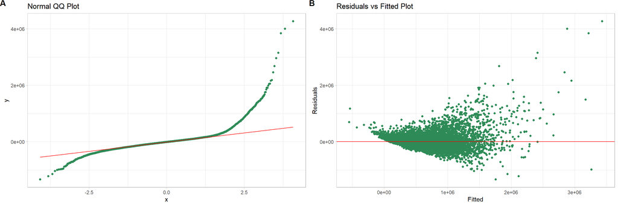

```r
m1_add <- lm("price~.", data=housing_data_clean_df)
draw_plots(m1_add)
```

- Based on the statistics and the plots we see that some kind of transformation for the response is necessary.

### 2.2.2 Boxcox lambda identifications for response and predictors

#### 2.2.2.1 Response transformation identification

In order to figure out the transformation for the response, we find the lambda for it

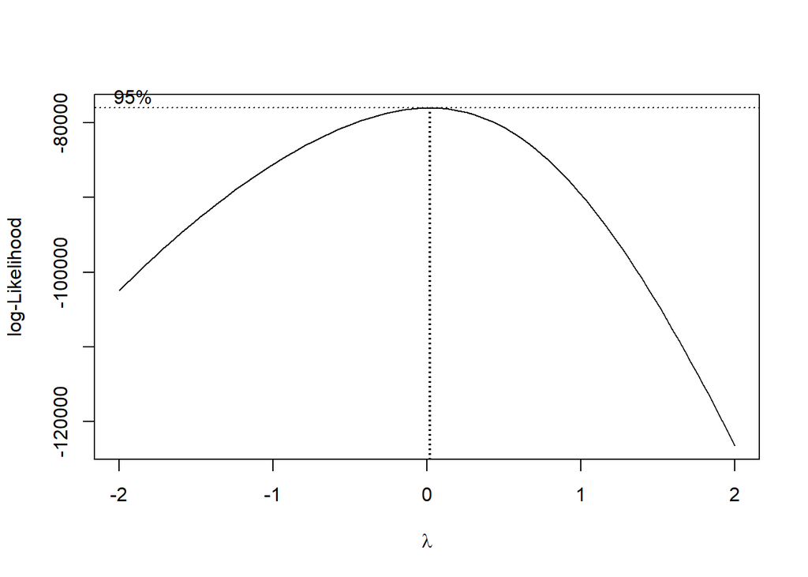

```r
boxcox(m1_add)
```

We know that the most common Box-Cox Transformations are

| $\lambda$ | Transformed Data |
| --- | --- |
| -2 | $y^{-2}$ |
| -1 | $y^{-1}$ |
| -.5 | $1 \over \sqrt y$ |
| 0 | ln(y) |
| .5 | $\sqrt y$ |
| 1 | y |
| 2 | $y^2$ |

since our $\lambda$ is close to 0 we will do log transformations

We redo the model and look at the diagnostics plots again

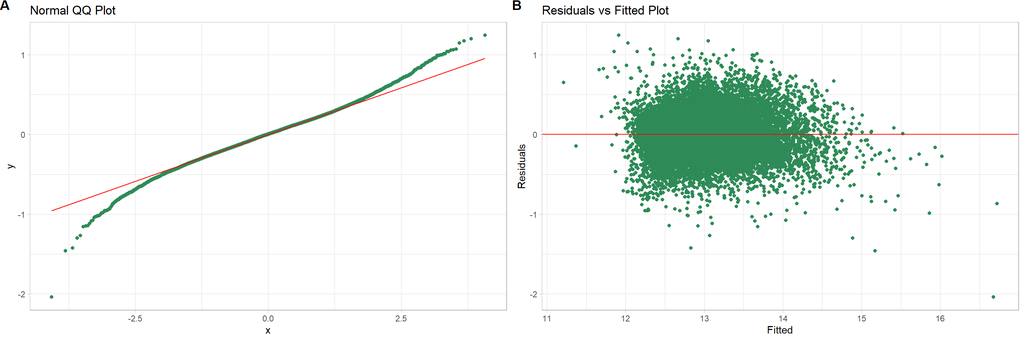

```r
m2 <- lm("log(price)~.", data=housing_data_clean_df)
draw_plots(m2)
```

We see that the plots and the statistics are a lot better, but there seems to be some scope for improvement.

#### 2.2.2.2 Identifyng the predictors that needs to be transformed

- We will identify the lambda transformations for the other columns we identified and using those variables as response, fit the model, but keep log(SalePrice) in the predictor with others

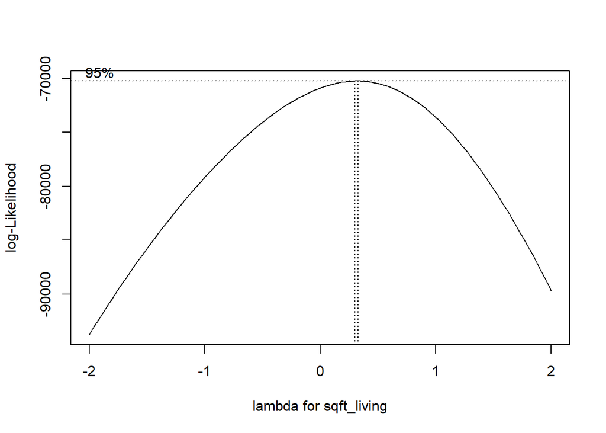

```r
m3 <- lm("sqft_living~.-price+log(price)", data = housing_data_clean_df)
boxcox(m3,xlab = "lambda for sqft_living")
```

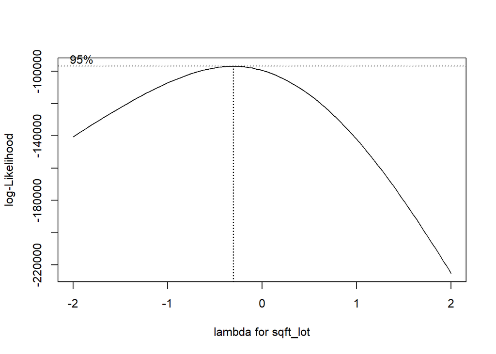

```r
m3 <- lm("sqft_lot~.-price+log(price)", data = housing_data_clean_df)
boxcox(m3,xlab = "lambda for sqft_lot")
```

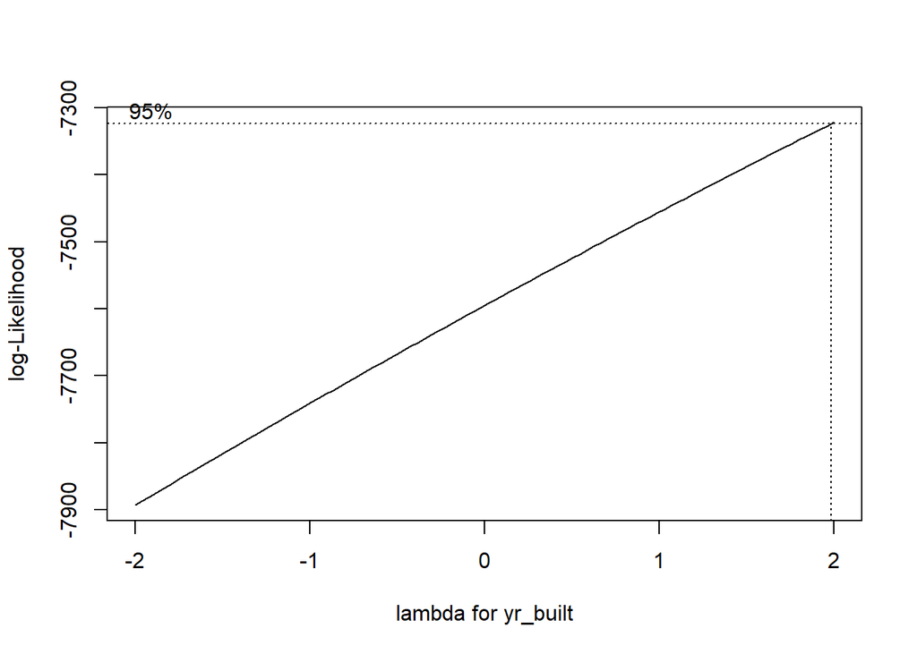

```r
m3 <- lm("yr_built~.-price+log(price)", data = housing_data_clean_df)
boxcox(m3,xlab = "lambda for yr_built")
```

## 2.3 Model Creation & Selection

### 2.3.1 Models - Simple, transformation, and using step

Based on the above analysis we create the below models to start with

```r
kc_trn_idx  = sample(nrow(housing_data_clean_df), size = trunc(0.80 * nrow(housing_data_clean_df)))
train_df = housing_data_clean_df[kc_trn_idx, ]
test_df = housing_data_clean_df[-kc_trn_idx, ]
```

- Build addtive model.

```r
m_additive <- lm(price~., data = train_df)
head(train_df)
```

```
##                  date  price bedrooms bathrooms sqft_living sqft_lot floors
## 1880  20141203T000000 835000        3      1.75        1490     3840    2.0
## 16856 20150422T000000 337000        3      1.75        1440    11364    1.0
## 15320 20140703T000000 605000        4      2.50        2800    10786    1.0
## 15457 20140507T000000 100000        2      1.00         910    22000    1.0
## 16092 20150306T000000 588000        4      1.75        2170     5750    1.0
## 1027  20140520T000000 271310        2      1.00         870     5340    1.5
##       waterfront view condition grade sqft_basement yr_built zipcode     lat
## 1880           0    0         3     8             0     1984   98033 47.6916
## 16856          0    0         3     7             0     1985   98155 47.7430
## 15320          0    0         3     8          1380     1970   98008 47.5959
## 15457          0    0         3     6             0     1956   98001 47.2777
## 16092          0    2         3     7           800     1975   98116 47.5668
## 1027           0    0         2     6             0     1906   98144 47.5849
##           long
## 1880  -122.214
## 16856 -122.328
## 15320 -122.116
## 15457 -122.252
## 16092 -122.383
## 1027  -122.302
```

- Build an interactive model
- Use zipcode as a factor variable because zipcode should not be considered as numeric and it influences the house price significantly.

```r
interactive_formula <- build_formula(train_df, "log(price)", c("price", "sqft_lot", "sqft_living","zipcode"), c("log(sqft_lot)", "log(sqft_living)","as.factor(zipcode)"))
interactive_formula
```

```
## [1] "log(price)  ~  date + bedrooms + bathrooms + floors + waterfront + view + condition + grade + sqft_basement + yr_built + lat + long + log(sqft_lot) + log(sqft_living) + as.factor(zipcode)"
```

```r
m_transform_1 <- lm(formula = interactive_formula, data = train_df)
coef(m_transform_1)
```

```
##             (Intercept)     date20140503T000000     date20140504T000000
##           -7.561997e+01            1.734016e-01           -2.761215e-02
##     date20140505T000000     date20140506T000000     date20140507T000000
##            1.713546e-02           -1.304131e-02           -2.831498e-03
##     date20140508T000000     date20140509T000000     date20140510T000000
##            4.066800e-02           -1.529218e-02            8.185577e-02
##     date20140511T000000     date20140512T000000     date20140513T000000
##           -2.670444e-02           -2.870400e-02            2.425313e-03
##     date20140514T000000     date20140515T000000     date20140516T000000
##            9.906430e-03           -5.159644e-03            5.071693e-03
##     date20140517T000000     date20140518T000000     date20140519T000000
##           -1.641868e-01            4.149744e-02            1.478679e-02
##     date20140520T000000     date20140521T000000     date20140522T000000
##            6.195441e-03           -1.068228e-02            5.787558e-03
##     date20140523T000000     date20140524T000000     date20140525T000000
##           -8.269129e-03            6.858748e-02           -1.388608e-01
##     date20140526T000000     date20140527T000000     date20140528T000000
##            5.678127e-03            1.925812e-02            1.817097e-02
##     date20140529T000000     date20140530T000000     date20140531T000000
##            1.835482e-02            1.648403e-02           -1.785474e-02
##     date20140601T000000     date20140602T000000     date20140603T000000
##            5.381867e-02            2.335272e-02            1.545940e-02
##     date20140604T000000     date20140605T000000     date20140606T000000
##            2.868218e-02            2.933194e-02            3.443895e-02
##     date20140607T000000     date20140608T000000     date20140609T000000
##           -8.976476e-02           -1.498406e-04            2.209851e-02
##     date20140610T000000     date20140611T000000     date20140612T000000
##            1.628671e-02            4.468226e-03            3.025168e-02
##     date20140613T000000     date20140614T000000     date20140615T000000
##            3.861008e-02            5.611008e-02           -3.076188e-02
##     date20140616T000000     date20140617T000000     date20140618T000000
##            1.856386e-02            2.019497e-02            4.717518e-02
##     date20140619T000000     date20140620T000000     date20140621T000000
##            1.777844e-02            7.019667e-02            4.507255e-02
##     date20140622T000000     date20140623T000000     date20140624T000000
##            4.848826e-02            8.352809e-03            2.897229e-02
##     date20140625T000000     date20140626T000000     date20140627T000000
##            1.317100e-02           -7.285332e-04            1.566988e-03
##     date20140628T000000     date20140629T000000     date20140630T000000
##            7.070375e-02           -1.004069e-01            2.338946e-02
```

[output cut: 245 more lines]

```
##            2.223315e-01            7.926631e-01            9.105980e-01
## as.factor(zipcode)98115 as.factor(zipcode)98116 as.factor(zipcode)98117
##            6.104667e-01            5.828603e-01            5.713988e-01
## as.factor(zipcode)98118 as.factor(zipcode)98119 as.factor(zipcode)98122
##            3.549145e-01            7.846881e-01            6.735363e-01
## as.factor(zipcode)98125 as.factor(zipcode)98126 as.factor(zipcode)98133
##            3.302480e-01            3.946296e-01            1.911101e-01
## as.factor(zipcode)98136 as.factor(zipcode)98144 as.factor(zipcode)98146
##            5.171473e-01            5.392688e-01            1.356140e-01
## as.factor(zipcode)98148 as.factor(zipcode)98155 as.factor(zipcode)98166
##            6.809197e-02            1.592117e-01            1.887311e-01
## as.factor(zipcode)98168 as.factor(zipcode)98177 as.factor(zipcode)98178
##           -3.962486e-02            3.221722e-01            6.999440e-02
## as.factor(zipcode)98188 as.factor(zipcode)98198 as.factor(zipcode)98199
##            1.187158e-02           -1.047700e-02            6.380752e-01
```

Now we use step backwards with aic for the above to find better versions of these models that are smaller than them

```r
m_additive_step <- step(m_additive, trace = 0)
(additive_formula_step <- formula(m_additive_step))
```

```
## price ~ bedrooms + bathrooms + sqft_living + floors + waterfront +
##     view + condition + grade + sqft_basement + yr_built + zipcode +
##     lat + long
```

```r
additive_formula_step
```

```
## price ~ bedrooms + bathrooms + sqft_living + floors + waterfront +
##     view + condition + grade + sqft_basement + yr_built + zipcode +
##     lat + long
```

```r
m_transform_1_step <- step(m_transform_1, trace = 0)
(interactive_formula_step <- formula(m_transform_1_step))
```

```
## log(price) ~ date + bedrooms + bathrooms + floors + waterfront +
##     view + condition + grade + sqft_basement + yr_built + lat +
##     long + log(sqft_lot) + log(sqft_living) + as.factor(zipcode)
## <environment: 0x000000002e17fb98>
```

```r
interactive_formula_step
```

```
## log(price) ~ date + bedrooms + bathrooms + floors + waterfront +
##     view + condition + grade + sqft_basement + yr_built + lat +
##     long + log(sqft_lot) + log(sqft_living) + as.factor(zipcode)
## <environment: 0x000000002e17fb98>
```

We now compare the key statistics of these models

```r
m_additive_result <- key_statistics(m_additive)
m_additive_step_result <- key_statistics(m_additive_step )

m_transform_1_result <- key_statistics(m_transform_1 )
m_transform_1_step_result <- key_statistics(m_transform_1_step)

df_result <- rbind(m_additive = m_additive_result,
                   m_additive_step = m_additive_step_result,
                   m_transform_1 = m_transform_1_result,
                   m_transform_1_step = m_transform_1_step_result)

knitr::kable(df_result)
```

|  | predictors | shapiro_Normalcy_test_pvalue | bptest_pval | RMSE | AdjustedR2 | AIC |
| --- | --- | --- | --- | --- | --- | --- |
| m_additive | 15 | 0 | 2.25489086928764e-274 | 198819.0824 | 0.693991973862867 | 422645.206252719 |
| m_additive_step | 13 | 0 | 0 | 201302.0576 | 0.692983187270308 | 422338.388181271 |
| m_transform_1 | 15 | 0 | 2.31386830419231e-129 | 0.1777 | 0.881942298039593 | -58842.558428942 |
| m_transform_1_step | 15 | 0 | 2.31386830419231e-129 | 0.1777 | 0.881942298039593 | -58842.558428942 |

Looking at the above table, we can clearly see that the additive model isnt yielding a good model. The RMSE is extremely high. Hence we will discard this model for now.

#### 2.3.1.1 Anova test

In order to confirm that the model generated using step (m_transform_1_step) is a better model than the m_transform_1 model, we will do an anova test

```r
anova(m_transform_1, m_transform_1_step)
```

```
## Analysis of Variance Table
##
## Model 1: log(price) ~ date + bedrooms + bathrooms + floors + waterfront +
##     view + condition + grade + sqft_basement + yr_built + lat +
##     long + log(sqft_lot) + log(sqft_living) + as.factor(zipcode)
## Model 2: log(price) ~ date + bedrooms + bathrooms + floors + waterfront +
##     view + condition + grade + sqft_basement + yr_built + lat +
##     long + log(sqft_lot) + log(sqft_living) + as.factor(zipcode)
##   Res.Df    RSS Df Sum of Sq F Pr(>F)
## 1  16840 545.97
## 2  16840 545.97  0         0
```

#### 2.3.1.2 Model selection

As we concluded above, we will use m_transform_1_step model going forward. Below is the formula of the model selected.

```r
formula(m_transform_1_step)
```

```
## log(price) ~ date + bedrooms + bathrooms + floors + waterfront +
##     view + condition + grade + sqft_basement + yr_built + lat +
##     long + log(sqft_lot) + log(sqft_living) + as.factor(zipcode)
## <environment: 0x000000002e17fb98>
```

### 2.3.2 Checking the significance of individual parameters for selected model

Looking at the diagnostics, we can improve the model little better. We will now look at the signficance of the parameters of this model to see if we can eliminate any predictors

```r
predictors <- coef(summary(m_transform_1_step))[,"Pr(>|t|)"]
#names(predictors)
```

We will use alpha = 0.01 We now identify the individual columns that have p-value of greater than 0.01 and remove them from the dataset to create another model

```r
names(predictors[predictors>.01])
```

```
##   [1] "date20140503T000000"     "date20140504T000000"
##   [3] "date20140505T000000"     "date20140506T000000"
##   [5] "date20140507T000000"     "date20140508T000000"
##   [7] "date20140509T000000"     "date20140510T000000"
##   [9] "date20140511T000000"     "date20140512T000000"
##  [11] "date20140513T000000"     "date20140514T000000"
##  [13] "date20140515T000000"     "date20140516T000000"
##  [15] "date20140517T000000"     "date20140518T000000"
##  [17] "date20140519T000000"     "date20140520T000000"
##  [19] "date20140521T000000"     "date20140522T000000"
##  [21] "date20140523T000000"     "date20140524T000000"
##  [23] "date20140525T000000"     "date20140526T000000"
##  [25] "date20140527T000000"     "date20140528T000000"
##  [27] "date20140529T000000"     "date20140530T000000"
##  [29] "date20140531T000000"     "date20140601T000000"
```

[output cut: 156 more lines]

We will select all non-categorical variables that have $pvalue>.01$. We will not remove the zipcodes to avoid overfitting. Now we modify the formula of the model that is best so far, and remove the above identified predictors from it

```r
remove_columns <- c("floors")

f <- formula(m_transform_1_step)
predictor_list <- str_split(f, pattern = fixed(" + "))[[3]]
predictor_list <- predictor_list[!(predictor_list %in% remove_columns)]

predictor_list <- str_replace(predictor_list, "\n    ", "")

# create the formula
(sig_formula <- paste("log(price) ~ ", paste(predictor_list, collapse = ' + ')))
```

```
## [1] "log(price) ~  date + bedrooms + bathrooms + waterfront + view + condition + grade + sqft_basement + yr_built + lat + long + log(sqft_lot) + log(sqft_living) + as.factor(zipcode)"
```

Now we use the above formula to create the model

```r
m_transform_1_step_sig <- lm(sig_formula, data = train_df)
```

#### 2.3.2.1 Anova test

We do an anova test between the two models to make sure we have not discarded significant predictors

```r
anova(m_transform_1_step_sig, m_transform_1_step)
```

```
## Analysis of Variance Table
##
## Model 1: log(price) ~ date + bedrooms + bathrooms + waterfront + view +
##     condition + grade + sqft_basement + yr_built + lat + long +
##     log(sqft_lot) + log(sqft_living) + as.factor(zipcode)
## Model 2: log(price) ~ date + bedrooms + bathrooms + floors + waterfront +
##     view + condition + grade + sqft_basement + yr_built + lat +
##     long + log(sqft_lot) + log(sqft_living) + as.factor(zipcode)
##   Res.Df    RSS Df Sum of Sq      F  Pr(>F)
## 1  16841 546.15
## 2  16840 545.97  1    0.1845 5.6909 0.01706 *
## ---
## Signif. codes:  0 '***' 0.001 '**' 0.01 '*' 0.05 '.' 0.1 ' ' 1
```

Based on the result of the anova test, we can move ahead with m_transform_1_step_sig model as we can reduce one variable.

#### 2.3.2.2 Diagnostic comparison

Now we will compare the key stats of the 2 models

```r
m_transform_1_step_result <- key_statistics(m_transform_1_step )
m_transform_1_step_sig_result <- key_statistics(m_transform_1_step_sig )
df_result <- rbind(m_transform_1_step=m_transform_1_step_result, m_transform_1_step_sig=m_transform_1_step_sig_result)

knitr::kable(df_result)
```

|  | predictors | shapiro_Normalcy_test_pvalue | bptest_pval | RMSE | AdjustedR2 | AIC |
| --- | --- | --- | --- | --- | --- | --- |
| m_transform_1_step | 15 | 0 | 2.31386830419231e-129 | 0.1777 | 0.881942298039593 | -58842.558428942 |
| m_transform_1_step_sig | 14 | 0 | 8.89419109103235e-125 | 0.1777 | 0.881909414356493 | -58838.7164673178 |

### 2.3.3 Variance Inflation factor identification

We look at variance inflation factors, and filter by only vifs that are >5

```r
faraway::vif(m_transform_1_step_sig)[faraway::vif(m_transform_1_step_sig)>5]
```

```
##                     lat                    long        log(sqft_living)
##               66.426742               35.102449                5.418600
## as.factor(zipcode)98004 as.factor(zipcode)98006 as.factor(zipcode)98008
##                6.464035                8.116132                6.538272
## as.factor(zipcode)98011 as.factor(zipcode)98014 as.factor(zipcode)98019
##                7.646645                5.850774                9.255770
## as.factor(zipcode)98027 as.factor(zipcode)98028 as.factor(zipcode)98029
##                7.103785               10.221656                7.301124
## as.factor(zipcode)98033 as.factor(zipcode)98034 as.factor(zipcode)98038
##               11.917605               16.703274                5.736179
## as.factor(zipcode)98045 as.factor(zipcode)98052 as.factor(zipcode)98053
##                7.624713               16.220769               13.253342
## as.factor(zipcode)98056 as.factor(zipcode)98059 as.factor(zipcode)98065
##                5.025322                5.479538                8.660771
## as.factor(zipcode)98072 as.factor(zipcode)98074 as.factor(zipcode)98075
##               10.897093               11.276919                8.523922
## as.factor(zipcode)98077 as.factor(zipcode)98103 as.factor(zipcode)98105
##                8.659094               15.709728                6.244209
## as.factor(zipcode)98107 as.factor(zipcode)98112 as.factor(zipcode)98115
##                7.434858                5.936750               15.532789
## as.factor(zipcode)98116 as.factor(zipcode)98117 as.factor(zipcode)98118
##                5.866864               15.227656                6.736699
## as.factor(zipcode)98122 as.factor(zipcode)98125 as.factor(zipcode)98126
##                6.059238               12.898987                5.088671
## as.factor(zipcode)98133 as.factor(zipcode)98144 as.factor(zipcode)98155
##               16.287993                6.178375               15.885532
## as.factor(zipcode)98177 as.factor(zipcode)98199
##                9.284080                8.031958
```

### 2.3.4 Influential points identification and handling

We can check the high influence points and investigate them

```r
influentials <- which(cooks.distance(m_transform_1_step_sig) > (4 / length(cooks.distance(m_transform_1_step_sig))))
length(influentials)
```

```
## [1] 867
```

As an experiment we try and remove the influentials and see what impact this has on the diagnostics

```r
train_df_no_inf <- train_df[-influentials,]
train_df_inf <- train_df[influentials,]

model_no_inf <- lm(formula(m_transform_1_step_sig), data = train_df_no_inf)
formula(model_no_inf)
```

```
## log(price) ~ date + bedrooms + bathrooms + waterfront + view +
##     condition + grade + sqft_basement + yr_built + lat + long +
##     log(sqft_lot) + log(sqft_living) + as.factor(zipcode)
## <environment: 0x000000002a384408>
```

#### 2.3.4.1 Key Statistics Comparison

Now we compare the key statistics data

```r
m_transform_1_step_sig_result <- key_statistics(m_transform_1_step_sig )
model_no_inf_result <- key_statistics(model_no_inf )

df_result <- rbind(m_transform_1_step_sig = m_transform_1_step_sig_result,
                   model_no_inf = model_no_inf_result)

knitr::kable(df_result)
```

|  | predictors | shapiro_Normalcy_test_pvalue | bptest_pval | RMSE | AdjustedR2 | AIC |
| --- | --- | --- | --- | --- | --- | --- |
| m_transform_1_step_sig | 14 | 0 | 8.89419109103235e-125 | 0.1777 | 0.881909414356493 | -58838.7164673178 |
| model_no_inf | 14 | 0 | 5.23539832476954e-135 | 0.1451 | 0.914248252612016 | -62555.2070290511 |

## 2.4 Selected model

```r
#formula(model_no_inf)
```

## 2.5 Predicting using the test data from the model and comparing efficiency – For some strange reason this is resulting in error.

```r
#test_df=sample_n(housing_data_clean_df, 5000)
#table = data.frame(Model = c("Interaction"),
#                   Train_RMSE = c(sqrt(mean((train_df_no_inf$price - predict(model_no_inf, train_df_no_inf)) ^ 2))),
#                   Test_RMSE = c(sqrt(mean((test_df$price - predict(model_no_inf, test_df)) ^ 2)))
#)
#knitr::kable(table, caption = "RMSE")
```

# 3 Results

## 3.1 Comparison of all models

```r
final_statistics <- rbind(m_additive = m_additive_result,
                   m_additive_step = m_additive_step_result,
                   m_transform_1 = m_transform_1_result,
                   m_transform_1_step = m_transform_1_step_result,
                   m_transform_1_step_sig = m_transform_1_step_sig_result,
                   model_no_inf = model_no_inf_result)

knitr::kable(final_statistics)
```

|  | predictors | shapiro_Normalcy_test_pvalue | bptest_pval | RMSE | AdjustedR2 | AIC |
| --- | --- | --- | --- | --- | --- | --- |
| m_additive | 15 | 0 | 2.25489086928764e-274 | 198819.0824 | 0.693991973862867 | 422645.206252719 |
| m_additive_step | 13 | 0 | 0 | 201302.0576 | 0.692983187270308 | 422338.388181271 |
| m_transform_1 | 15 | 0 | 2.31386830419231e-129 | 0.1777 | 0.881942298039593 | -58842.558428942 |
| m_transform_1_step | 15 | 0 | 2.31386830419231e-129 | 0.1777 | 0.881942298039593 | -58842.558428942 |
| m_transform_1_step_sig | 14 | 0 | 8.89419109103235e-125 | 0.1777 | 0.881909414356493 | -58838.7164673178 |
| model_no_inf | 14 | 0 | 5.23539832476954e-135 | 0.1451 | 0.914248252612016 | -62555.2070290511 |

We also look at the Q-Q/Fitted vs Residuals plot of our selected model

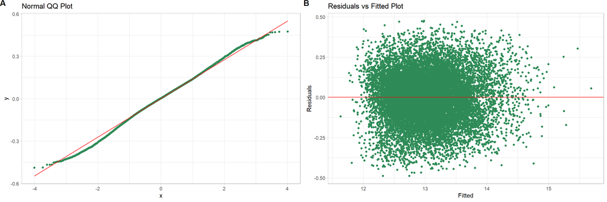

```r
draw_plots(model_no_inf)
```

# 4 Discussion

After looking at the diagnostics plot we come to the final conclusion that we have a good enough model

```r
knitr::kable(data.frame(key_statistics(model_no_inf)))
```

| predictors | shapiro_Normalcy_test_pvalue | bptest_pval | RMSE | AdjustedR2 | AIC |
| --- | --- | --- | --- | --- | --- |
| 14 | 0 | 0 | 0.1451 | 0.9142483 | -62555.21 |